# Species Distribution Model Demo

## Species Distribution Models

- Where species are expect to occur
- Can be based on lots of things, but often just environmental variables
- Very simple version - do not use this in production

## Load some packages

- `dismo` is the major package for SDM in R

```r
library(ggplot2)
library(dismo)
library(dplyr)
```

## Data

- Two kinds of data for SDMS
- Locations for where a species occurs
  - And ideally where it is absent
  - When no absences make fake absenses called “background”
- Spatial data on predictor variables
  - Most commonly temp & precip based
  - But that is mostly convenience based, not biology based
  - Need both current and future (forecast) values
- Location data
  - Breeding Bird Survey of North America on Hooded Warbler
- Environmental data
  - Temperature (minimum) & precipitation
  - CMIP5 50 year forecasts (coupled model intercomparison project)
- Download data from https://course.naturecast.org/data/sdm_data.zip

```r
hooded_warb_data = read.csv("hooded_warb_locations.csv")
env_data_stacked_current = stack("env_current.grd")
env_data_stacked_forecast = stack("env_forecast.grd")
head(hooded_warb_data)
```

```
##         lon      lat present
## 1 -87.60414 34.86869       1
## 2 -87.19129 34.63867       1
## 3 -87.73333 34.80000       0
## 4 -87.05924 34.02979       1
## 5 -86.49341 34.20167       1
## 6 -86.68555 34.50129       0
```

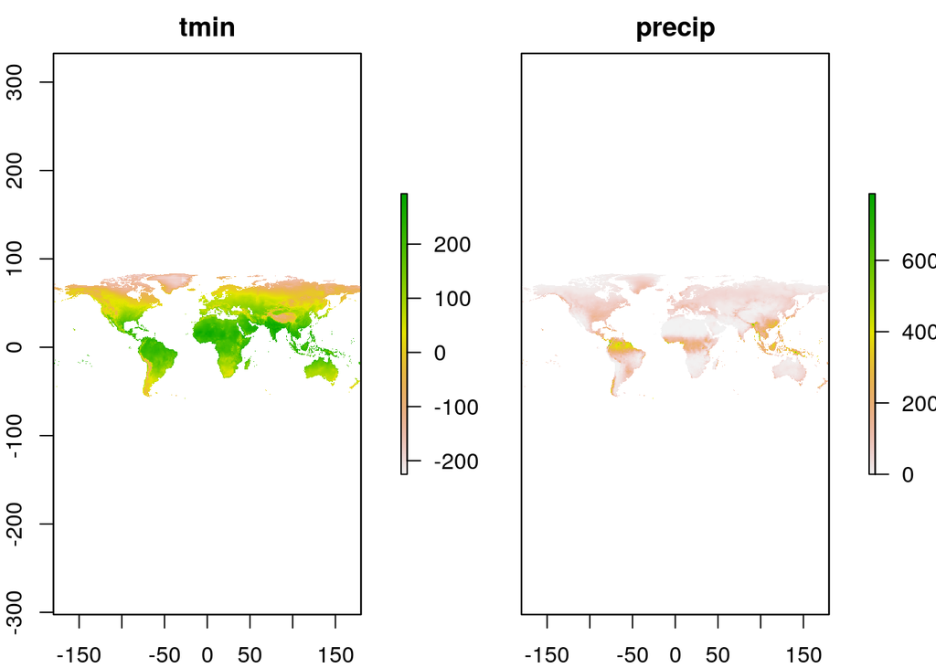

```r
plot(env_data_stacked_current)
```

## Determine environment where species is (and isn’t)

- Combine the two data types
- Info on the environment where a species occur and where it doesn’t

```r
hooded_warb_locations = select(hooded_warb_data, lon, lat)
hooded_warb_env = data.frame(extract(env_data_stacked_current, hooded_warb_locations))
hooded_warb_data = cbind(hooded_warb_data, hooded_warb_env)
```

- Can look at this in a 2D case

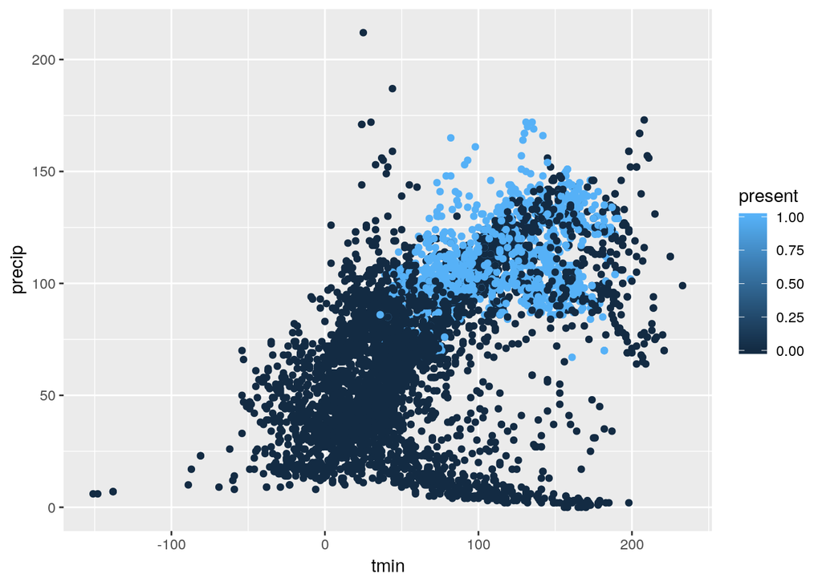

```r
ggplot(hooded_warb_data, aes(x = tmin, y = precip, color = present)) +
  geom_point()
```

* Find regions of climate space where the species is likely to occur * This species is associated with high temps and precips

## Modeling species distribution

- Many different ways to model probability of species presence
- Look at one of the simplest
  - Generalized linear modeling
  - Multivariate logistic regression

```r
logistic_regr_model <- glm(present ~ tmin + precip,
                           family = binomial(link = "logit"),
                           data=hooded_warb_data)
summary(logistic_regr_model)
```

```
##
## Call:
## glm(formula = present ~ tmin + precip, family = binomial(link = "logit"),
##     data = hooded_warb_data)
##
## Deviance Residuals:
##     Min       1Q   Median       3Q      Max
## -2.6098  -0.5055  -0.2265  -0.1149   2.3704
##
## Coefficients:
##               Estimate Std. Error z value Pr(>|z|)
## (Intercept) -6.1321879  0.1817786  -33.73   <2e-16 ***
## tmin         0.0115134  0.0009303   12.38   <2e-16 ***
## precip       0.0410928  0.0019430   21.15   <2e-16 ***
## ---
## Signif. codes:  0 '***' 0.001 '**' 0.01 '*' 0.05 '.' 0.1 ' ' 1
##
## (Dispersion parameter for binomial family taken to be 1)
##
##     Null deviance: 5773.6  on 5688  degrees of freedom
## Residual deviance: 3886.1  on 5686  degrees of freedom
##   (1 observation deleted due to missingness)
## AIC: 3892.1
##
## Number of Fisher Scoring iterations: 6
```

## Evaluate the model performance

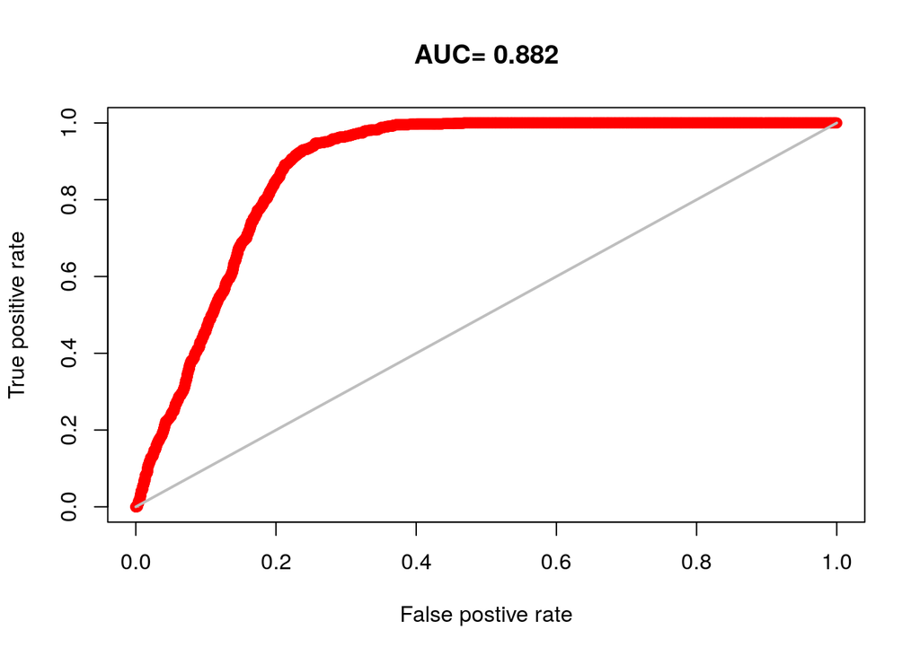

```r
presence_data = filter(hooded_warb_data, present == 1)
absence_data = filter(hooded_warb_data, present == 0)
evaluation <- evaluate(presence_data, absence_data, logistic_regr_model)
plot(evaluation, 'ROC')
```

- Looks good, but is biased when using absenses from large scales

## Plot the model predictions

- Use the overloaded `predict` function from the `raster` package
- Arguments
  - Raster of environmental conditions
  - Model
  - `type = "response"` to get probabilities

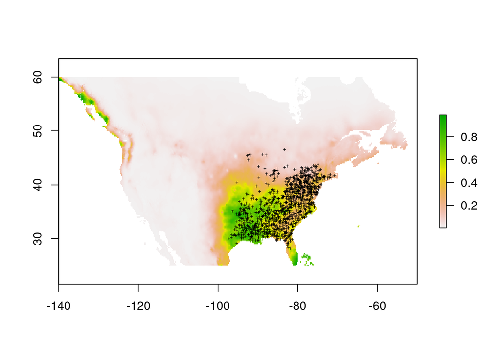

```r
predictions <- predict(env_data_stacked_current, logistic_regr_model, type = "response")
present <- select(filter(hooded_warb_data, present == 1), lon, lat)
plot(predictions, ext = extent(-140, -50, 25, 60))
points(present, pch='+', cex = 0.5)
```

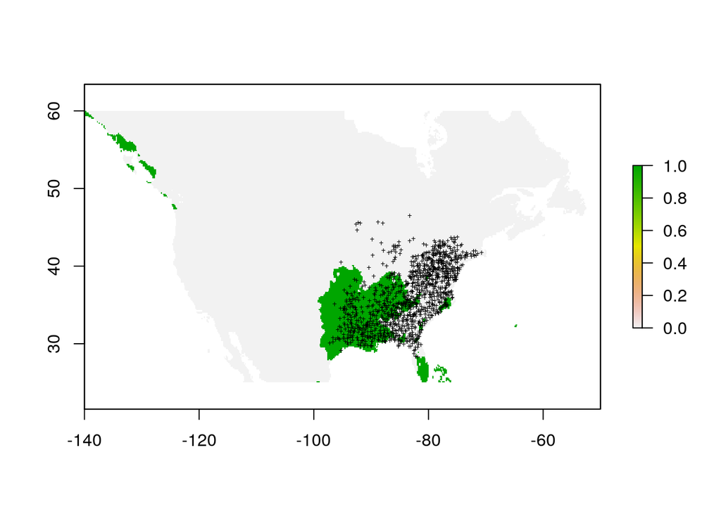

```r
plot(predictions > 0.5, ext = extent(-140, -50, 25, 60))
points(present, pch='+', cex = 0.5)
```

- Can also choose a different threshold to give better classification
- E.g., > 25% probability of occuring
- Can choose this automatically

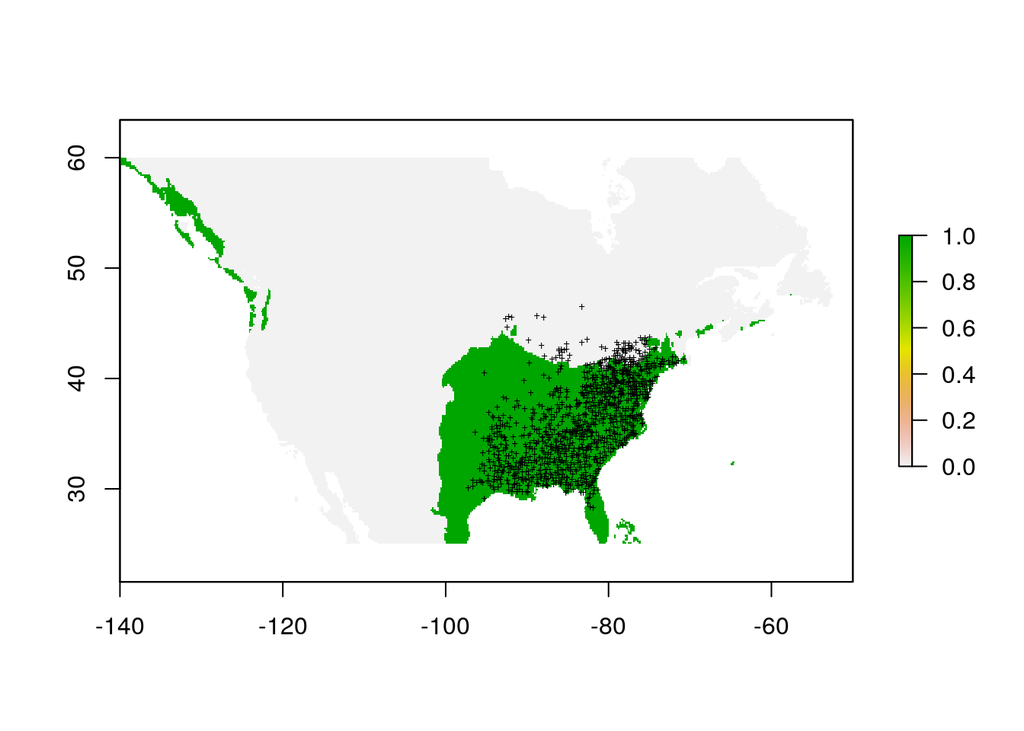

```r
tr <- threshold(evaluation, 'prevalence')
plot(predictions > tr, ext = extent(-140, -50, 25, 60))
points(present, pch='+', cex = 0.5)
```

## Make forecasts

- Use forecast data for future environmental conditions
- CMIP5

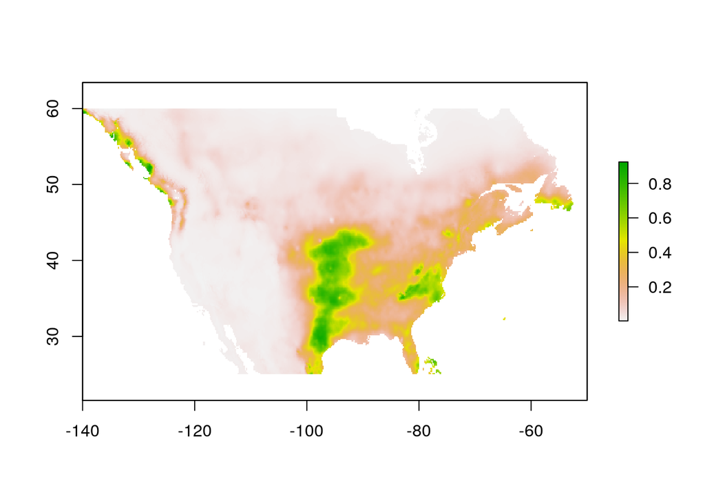

```r
predictions <- predict(env_data_stacked_forecast, logistic_regr_model, type = "response")
plot(predictions, ext = extent(-140, -50, 25, 60))
```

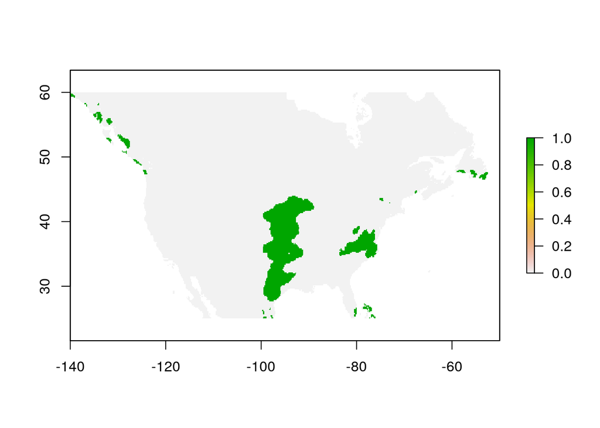

```r
plot(predictions > 0.5, ext = extent(-140, -50, 25, 60))
```

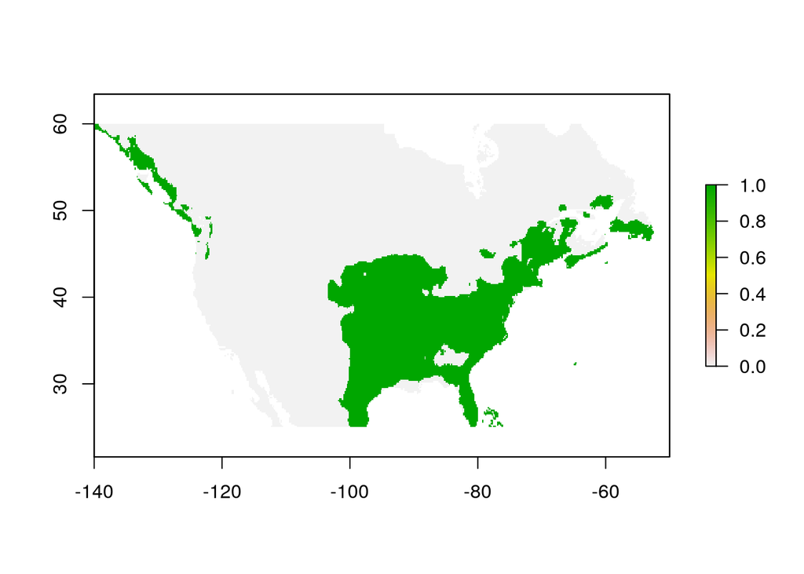

```r
plot(predictions > tr, ext = extent(-140, -50, 25, 60))
```